# SF Vignette

Glen Pridham 2023 Rutengroup

Tutorial on using sf.R. SF: stochastic finite model.

Purpose: what is the central fitting function and how do we use it?

What is NOT covered: -how to reshape data -how to impute missing values See the advanced fitsf vignette for the above.

# Fitting data - the FitSF function

```r
outputDir = ""  #enter the file location for the SF (github) files here
source(sprintf("%s/sf.R",outputDir))
```

We start with some data. Our algorithm is designed to handle longitudinal data with regular sampling. Such data is efficiently stored in 3d arrays.

The simplest form for us to begin with is thus 3d arrays.

```r
y  = readRDS(sprintf("%s/test_y_array.rds",outputDir))
x  = readRDS(sprintf("%s/test_x_array.rds",outputDir))
#dt = readRDS(sprintf("%s/test_dt.csv",outputDir)) #we can load or make our own dt
dt = x[,"age",-1] - x[,"age",-dim(x)[3]]
print(dim(x))
```

```
[1] 1000    2   20
```

```r
print(dim(y))
```

```
[1] 1000    5   20
```

```r
print("Predictors / longitudinal variables:")
```

```
[1] "Predictors / longitudinal variables:"
```

```r
print(colnames(y))
```

```
[1] "y01" "y02" "y03" "y04" "y05"
```

```r
print("covariates (can be time-varying or not):")
```

```
[1] "covariates (can be time-varying or not):"
```

```r
print(colnames(x))
```

```
[1] "age" "sex"
```

To fit we use the master function FitSF

```r
sf = FitSF(y=y,x=x,dt=dt)
```

```
[1] "Imputing age in column age"
[1] "Age imputation correct?"
[1] TRUE
[1] "Iterations selected: 5.0"
[1] "Noise precision matrix has been supplied..."
[1] "NAs to replace: 0, total NAs: 0 (diff: 0)"
[1] "NAs to replace: 0, NAs replaced by initial imputation: 0 (imputed: NaN%)"
[1] "initial imputation options:"
list()
[1] "NAs after iterating:"
[1] 0
```

The primary parameters of the model are an interaction network and equilibrium positions for each variable.

```r
print("Network:")
```

```
[1] "Network:"
```

```r
print(round(sf$W,3))
```

```
       y01    y02    y03    y04    y05
y01 -0.362 -0.033  0.089  0.063  0.004
y02 -0.035 -0.347  0.104  0.086 -0.089
y03  0.080  0.110 -0.636 -0.143 -0.013
y04  0.066  0.090 -0.146 -0.748  0.127
y05  0.005 -0.092 -0.010  0.130 -0.313
```

```r
print("Equilibrium positions:")
```

```
[1] "Equilibrium positions:"
```

```r
print(round(sf$lambda[,"mu0"],3))
```

```
   y01    y02    y03    y04    y05
-0.454 -0.566 -1.868  0.465 -0.506
```

Equilibrium positions can depend on covariates

```r
print("Equilibrium position covariates:")
```

```
[1] "Equilibrium position covariates:"
```

```r
print(round(sf$lambda[,-1],3))
```

```
       age    sex
y01  0.005 -0.435
y02  0.011 -0.260
y03  0.012 -0.234
y04 -0.007 -0.604
y05  0.002  0.078
```

For example, y01 has a large, negative sex effect. This means that if sex = 1 (female) then the equilibrium position value will be lower than sex = 0 (male).

As an example, we plot the mean along with the equilibrium positions (lines).

```r
sex0 = x[,"sex",1] == 0
plot(apply(x[sex0,"age",],2,mean),apply(y[sex0,1,],2,mean),xlab="Age",ylab=colnames(y)[1],ylim=c(-1.5,1.5))
points(apply(x[!sex0,"age",],2,mean),apply(y[!sex0,1,],2,mean),xlab="Age",ylab=colnames(y)[1],pch=2,col=2)
```

```r
curve(sf$lambda[1,"mu0"]+sf$lambda[1,"age"]*x,add=T,col=1)
curve(sf$lambda[1,"mu0"]+sf$lambda[1,"age"]*x+sf$lambda[1,"sex"],add=T,col=2,lty=2)
```

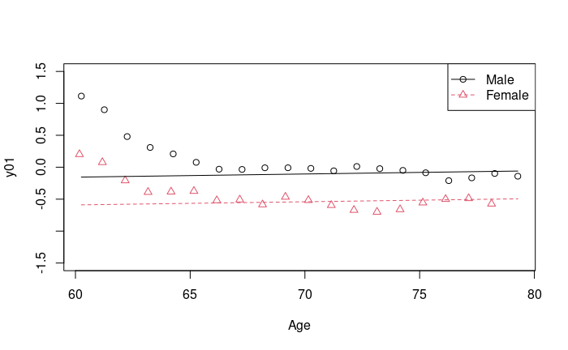

```r
legend("topright",c("Male","Female"),col=1:2,lty=1:2,pch=1:2)
```

There are several ways to visualize the resulting network. Probably the simplest way is as a matrix of weights.

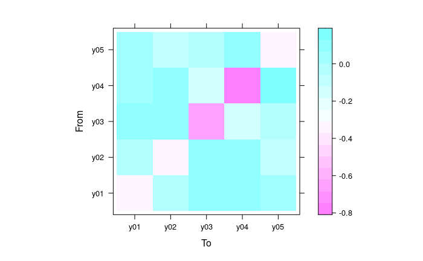

```r
library(lattice)
levelplot(sf$W,xlab="To",ylab="From")
```

We generally don’t want to keep all of the links. FitSF by default includes error estimates assuming asymptotic normality, we can use this to drop non-significant links. The asymptotic errors generally unreliable and bootstrap should be used for robust results. For our purposes they suffice to give an idea of which links are least likely.

Typically we’d pick the 95% confidence interval, but since the error estimates are very small we instead demand 99.9% CI.

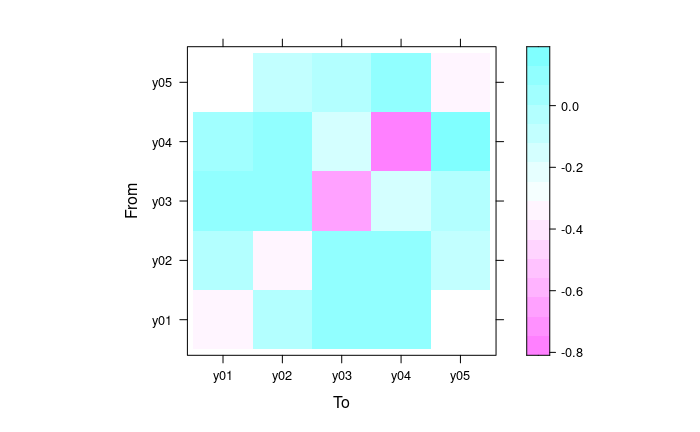

```r
library(lattice)
network = sf$W
#network[abs(sf$W) < qnorm(.975)*sf$dW] = NA #95% confidence
network[abs(sf$W) < qnorm(.9995)*sf$dW] = NA #99.9% CI
levelplot(network,xlab="To",ylab="From")
```